# Presentation of the Ford GoBike Data Analysis

## by Chinemelum Nwaeze

## Investigation Overview

> The major variable of interest in this analysis is the time spent cycling. This analysis sought to determine how other variables like gender and age affect the time spent cycling

## Dataset Overview

> This dataset consist of data about cyclers in the year 2019 and their usage of bike as recorded by Ford GoBike. There was a total of over 180,000 records, this was reduced to over 160,000 after wrangling processes were carried out

## Distribution of time spent cycling

> The distribution of the time spent cycling seen in the duration_mins column is unimodal having 6 minutes as the most time period spent by cyclers cycling. The time ranges from 1 minute to 25 minutes. As time spent cycling increases, the number of cyclers reduces.

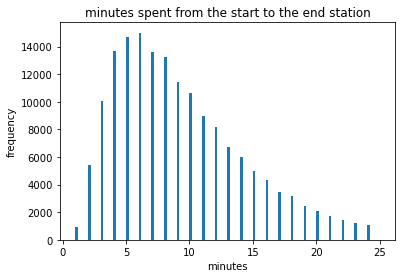

## Gender distribution

> Gender here consist of Male, Female and Others. Since I am looking at proportions of a whole, pie chart is the best visuals to convey the message. Therein the number of male cyclers recorded was more than half of the total cyclers.

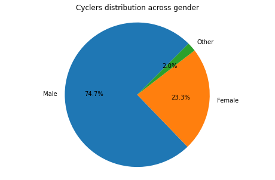

## Gender Versus Duration

The time spent by each gender flows in the same direction with more cyclers in each gender distribution spending lesser time cycling. Going to show that gender holds little on the duration spent cycling. The male gender distribution chat is more visible because there are more male in the observations recorded.

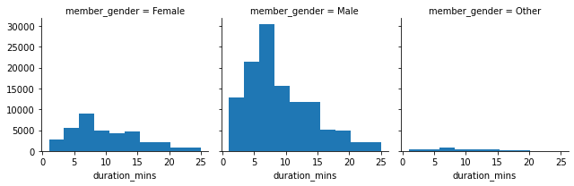

## Age versus Time Duration

For ease of visualization and interpretation, I have grouped the ages into ranges of 10. The chart shows we have more of those in the age bracket of 28 - 37, but this does not mean that they spend more time cycling. Age here also has no significant impact on the time spent cycling

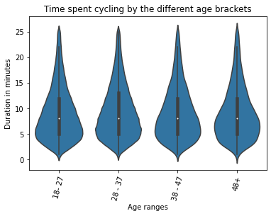

## Time spent by each gender given the user type

I brought in the user type variable here, which judges if the cycler is a subscriber or a customer and then looks at the time spent by each gender distributio of the user type while cycling. The chart below shows customers to cycle for a longer period of time than the subscribers irrespective of the gender, it also shows more female cycling for longer period than other gender supporting the previous analysis.

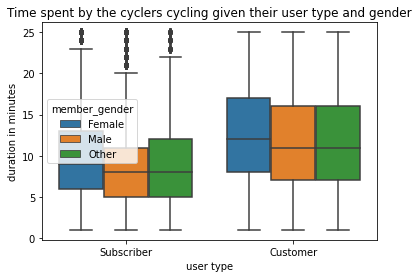

### Time spent cycling by partakers and non-partakers in the bike sharing program given user type

The white space in the second quadrant seen below goes to affirm that no customer partook in the bike share for all trip program. Despite this, customers spend on the average a longer period cycling than subscribers, subscribers who partook in the program spent the least time cycling.

[figure not shown]

Summarily neither gender nor age was a major determinant of the time spend cycling. The bike share for all trip program was strictly for subscribers. The number of cyclers subscribers who partook in the program was quite poor.